# Randomforest

### Introduction to Random Forest algorithm

Random forest is a supervised learning algorithm. It has two variations – one is used for classification problems and other is used for regression problems. It is one of the most flexible and easy to use algorithm. It creates decision trees on the given data samples, gets prediction from each tree and selects the best solution by means of voting. It is also a pretty good indicator of feature importance.

Random forest algorithm combines multiple decision-trees, resulting in a forest of trees, hence the name Random Forest. In the random forest classifier, the higher the number of trees in the forest results in higher accuracy.

### Random Forest algorithm intuition

Random forest algorithm intuition can be divided into two stages.

In the first stage, we randomly select “k” features out of total m features and build the random forest. In the first stage, we proceed as follows:-

##### 1.Randomly select k features from a total of m features where k < m.

##### 2.Among the k features, calculate the node d using the best split point.

##### 3.Split the node into daughter nodes using the best split.

##### 4.Repeat 1 to 3 steps until l number of nodes has been reached.

##### 5.Build forest by repeating steps 1 to 4 for n number of times to create n number of trees.

In the second stage, we make predictions using the trained random forest algorithm.

##### 1.We take the test features and use the rules of each randomly created decision tree to predict the outcome and stores the predicted outcome.

##### 2.Then, we calculate the votes for each predicted target.

##### 3.Finally, we consider the high voted predicted target as the final prediction from the random forest algorithm.

### Random Forest algorithm intuition

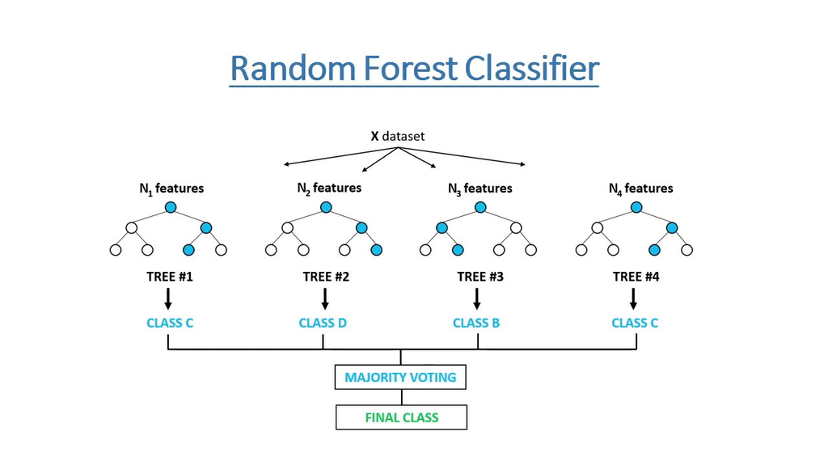

#### The advantages of Random forest algorithm are as follows:-

Random forest algorithm can be used to solve both classification and regression problems.

It is considered as very accurate and robust model because it uses large number of decision-trees to make predictions.

Random forests takes the average of all the predictions made by the decision-trees, which cancels out the biases. So, it does not suffer from the overfitting problem.

Random forest classifier can handle the missing values. There are two ways to handle the missing values. First is to use median values to replace continuous variables and second is to compute the proximity-weighted average of missing values.

Random forest classifier can be used for feature selection. It means selecting the most important features out of the available features from the training dataset.

#### The disadvantages of Random Forest algorithm are listed below:-

The biggest disadvantage of random forests is its computational complexity. Random forests is very slow in making predictions because large number of decision-trees are used to make predictions. All the trees in the forest have to make a prediction for the same input and then perform voting on it. So, it is a time-consuming process.

The model is difficult to interpret as compared to a decision-tree, where we can easily make a prediction as compared to a decision-tree.

### Feature selection with Random Forests

Random forests algorithm can be used for feature selection process. This algorithm can be used to rank the importance of variables in a regression or classification problem.

We measure the variable importance in a dataset by fitting the random forest algorithm to the data. During the fitting process, the out-of-bag error for each data point is recorded and averaged over the forest.

The importance of the j-th feature was measured after training. The values of the j-th feature were permuted among the training data and the out-of-bag error was again computed on this perturbed dataset. The importance score for the j-th feature is computed by averaging the difference in out-of-bag error before and after the permutation over all trees. The score is normalized by the standard deviation of these differences.

Features which produce large values for this score are ranked as more important than features which produce small values. Based on this score, we will choose the most important features and drop the least important ones for model building.

### Difference between Random Forests and Decision Trees

1.Random forests is a set of multiple decision-trees.

2.Decision-trees are computationally faster as compared to random forests.

3.Deep decision-trees may suffer from overfitting. Random forest prevents overfitting by creating trees on random forests.

4.Random forest is difficult to interpret. But, a decision-tree is easily interpretable and can be converted to rules.

### implementation

```python
import numpy as np
import pandas as pd
import matplotlib.pyplot as plt
import seaborn as sns
```

```python
df = pd.read_csv('car_evaluation.csv')
```

```python
col_names = ['buying', 'maint', 'doors', 'persons', 'lug_boot', 'safety', 'class']


df.columns = col_names

df
```

|  | buying | maint | doors | persons | lug_boot | safety | class |
| --- | --- | --- | --- | --- | --- | --- | --- |
| 0 | vhigh | vhigh | 2 | 2 | small | med | unacc |
| 1 | vhigh | vhigh | 2 | 2 | small | high | unacc |
| 2 | vhigh | vhigh | 2 | 2 | med | low | unacc |
| 3 | vhigh | vhigh | 2 | 2 | med | med | unacc |
| 4 | vhigh | vhigh | 2 | 2 | med | high | unacc |
| ... | ... | ... | ... | ... | ... | ... | ... |
| 1722 | low | low | 5more | more | med | med | good |
| 1723 | low | low | 5more | more | med | high | vgood |
| 1724 | low | low | 5more | more | big | low | unacc |
| 1725 | low | low | 5more | more | big | med | good |
| 1726 | low | low | 5more | more | big | high | vgood |

1727 rows × 7 columns

```python
for col in col_names:

    print(df[col].value_counts())
```

```
buying
high     432
med      432
low      432
vhigh    431
Name: count, dtype: int64
maint
high     432
med      432
low      432
vhigh    431
Name: count, dtype: int64
doors
3        432
4        432
5more    432
2        431
Name: count, dtype: int64
persons
4       576
more    576
2       575
Name: count, dtype: int64
lug_boot
med      576
big      576
small    575
Name: count, dtype: int64
safety
med     576
high    576
low     575
Name: count, dtype: int64
class
unacc    1209
acc       384
good       69
vgood      65
Name: count, dtype: int64
```

here are 7 variables in the dataset. All the variables are of categorical data type.

These are given by buying, maint, doors, persons, lug_boot, safety and class.

class is the target variable.

```python
df['class'].value_counts()
```

```
class
unacc    1209
acc       384
good       69
vgood      65
Name: count, dtype: int64
```

The class target variable is ordinal in nature.

```python
df.isnull().sum()
```

```
buying      0
maint       0
doors       0
persons     0
lug_boot    0
safety      0
class       0
dtype: int64
```

```python
X = df.drop(['class'], axis=1)

y = df['class']
```

```python
from sklearn.model_selection import train_test_split

X_train, X_test, y_train, y_test = train_test_split(X, y, test_size = 0.33, random_state = 42)
```

```python
X_train.shape, X_test.shape
```

```
((1157, 6), (570, 6))
```

```python
X_train.dtypes
```

```
buying      object
maint       object
doors       object
persons     object
lug_boot    object
safety      object
dtype: object
```

```python
X_train.head()
```

|  | buying | maint | doors | persons | lug_boot | safety |
| --- | --- | --- | --- | --- | --- | --- |
| 83 | vhigh | vhigh | 5more | 2 | med | low |
| 48 | vhigh | vhigh | 3 | more | med | med |
| 468 | high | vhigh | 3 | 4 | small | med |
| 155 | vhigh | high | 3 | more | med | low |
| 1043 | med | high | 4 | more | small | low |

```python
pip install category_encoders
```

[output not shown]

```python
import category_encoders as ce
```

```python
encoder = ce.OrdinalEncoder(cols=['buying', 'maint', 'doors', 'persons', 'lug_boot', 'safety'])


X_train = encoder.fit_transform(X_train)

X_test = encoder.transform(X_test)
```

```python
X_train.head()
```

|  | buying | maint | doors | persons | lug_boot | safety |
| --- | --- | --- | --- | --- | --- | --- |
| 83 | 1 | 1 | 1 | 1 | 1 | 1 |
| 48 | 1 | 1 | 2 | 2 | 1 | 2 |
| 468 | 2 | 1 | 2 | 3 | 2 | 2 |
| 155 | 1 | 2 | 2 | 2 | 1 | 1 |
| 1043 | 3 | 2 | 3 | 2 | 2 | 1 |

```python
X_test.head()
```

|  | buying | maint | doors | persons | lug_boot | safety |
| --- | --- | --- | --- | --- | --- | --- |
| 599 | 2 | 2 | 3 | 1 | 3 | 1 |
| 932 | 3 | 1 | 3 | 3 | 3 | 1 |
| 628 | 2 | 2 | 1 | 1 | 3 | 3 |
| 1497 | 4 | 2 | 1 | 3 | 1 | 2 |
| 1262 | 3 | 4 | 3 | 2 | 1 | 1 |

```python
from sklearn.ensemble import RandomForestClassifier



# instantiate the classifier

rfc = RandomForestClassifier(n_estimators = 10,random_state=0)



# fit the model

rfc.fit(X_train, y_train)



# Predict the Test set results

y_pred = rfc.predict(X_test)



# Check accuracy score

from sklearn.metrics import accuracy_score

print('Model accuracy score with 10 decision-trees : {0:0.4f}'. format(accuracy_score(y_test, y_pred)))
```

```
Model accuracy score with 10 decision-trees : 0.9474
```

```python
rfc_100 = RandomForestClassifier(n_estimators=100, random_state=0)



# fit the model to the training set

rfc_100.fit(X_train, y_train)



# Predict on the test set results

y_pred_100 = rfc_100.predict(X_test)



# Check accuracy score

print('Model accuracy score with 100 decision-trees : {0:0.4f}'. format(accuracy_score(y_test, y_pred_100)))
```

```
Model accuracy score with 100 decision-trees : 0.9649
```

```python
feature_scores = pd.Series(rfc.feature_importances_, index=X_train.columns).sort_values(ascending=False)

feature_scores
```

```
safety      0.305310
persons     0.223000
buying      0.183449
lug_boot    0.116261
maint       0.100492
doors       0.071489
dtype: float64
```

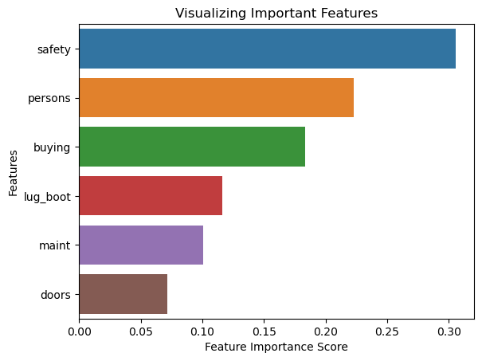

```python
sns.barplot(x=feature_scores, y=feature_scores.index)

plt.xlabel('Feature Importance Score')

plt.ylabel('Features')

plt.title("Visualizing Important Features")

plt.show()
```

```python
X = df.drop(['class', 'doors'], axis=1)#doors is less important

y = df['class']
```

```python
from sklearn.model_selection import train_test_split

X_train, X_test, y_train, y_test = train_test_split(X, y, test_size = 0.33, random_state = 42)
```

```python
encoder = ce.OrdinalEncoder(cols=['buying', 'maint', 'persons', 'lug_boot', 'safety'])


X_train = encoder.fit_transform(X_train)

X_test = encoder.transform(X_test)
```

```python
clf = RandomForestClassifier(n_estimators=10,random_state=0)



# fit the model to the training set

clf.fit(X_train, y_train)


# Predict on the test set results

y_pred = clf.predict(X_test)


# Check accuracy score

print('Model accuracy score with doors variable removed : {0:0.4f}'. format(accuracy_score(y_test, y_pred)))
```

```
Model accuracy score with doors variable removed : 0.9316
```

```python
X = df.drop(['class', 'maint'], axis=1)#doors is less important

y = df['class']
```

```python
from sklearn.model_selection import train_test_split

X_train, X_test, y_train, y_test = train_test_split(X, y, test_size = 0.33, random_state = 42)
```

```python
encoder = ce.OrdinalEncoder(cols=['buying', 'doors', 'persons', 'lug_boot', 'safety'])


X_train = encoder.fit_transform(X_train)

X_test = encoder.transform(X_test)
```

```python
clf = RandomForestClassifier(n_estimators=10,random_state=0)



# fit the model to the training set

clf.fit(X_train, y_train)


# Predict on the test set results

y_pred = clf.predict(X_test)


# Check accuracy score

print('Model accuracy score with doors variable removed : {0:0.4f}'. format(accuracy_score(y_test, y_pred)))
```

[output not shown]

```python
from sklearn.metrics import accuracy_score, confusion_matrix, precision_score, recall_score
```

```python
accuracy = accuracy_score(y_test, y_pred)

print("Accuracy:", accuracy)
```

[output not shown]

## About Dataset

Age: Age in years when a woman is pregnant.

SystolicBP: Upper value of Blood Pressure in mmHg, another significant attribute during pregnancy.

DiastolicBP: Lower value of Blood Pressure in mmHg, another significant attribute during pregnancy.

BS: Blood glucose levels is in terms of a molar concentration, mmol/L.

HeartRate: A normal resting heart rate in beats per minute.

Risk Level: Predicted Risk Intensity Level during pregnancy considering the previous attribute.

## Classification

```python
import pandas as pd
import numpy as np
import seaborn as sns
import matplotlib.pyplot as plt
```

```python
data = pd.read_csv("Maternal_Health_Risk.csv")
```

```python
data.head()
```

|  | Age | SystolicBP | DiastolicBP | BS | BodyTemp | HeartRate | RiskLevel |
| --- | --- | --- | --- | --- | --- | --- | --- |
| 0 | 25 | 130 | 80 | 15.0 | 98.0 | 86 | high risk |
| 1 | 35 | 140 | 90 | 13.0 | 98.0 | 70 | high risk |
| 2 | 29 | 90 | 70 | 8.0 | 100.0 | 80 | high risk |
| 3 | 30 | 140 | 85 | 7.0 | 98.0 | 70 | high risk |
| 4 | 35 | 120 | 60 | 6.1 | 98.0 | 76 | low risk |

```python
data.info()
```

```
<class 'pandas.core.frame.DataFrame'>
RangeIndex: 1014 entries, 0 to 1013
Data columns (total 7 columns):
 #   Column       Non-Null Count  Dtype
---  ------       --------------  -----
 0   Age          1014 non-null   int64
 1   SystolicBP   1014 non-null   int64
 2   DiastolicBP  1014 non-null   int64
 3   BS           1014 non-null   float64
 4   BodyTemp     1014 non-null   float64
 5   HeartRate    1014 non-null   int64
 6   RiskLevel    1014 non-null   object
dtypes: float64(2), int64(4), object(1)
memory usage: 55.6+ KB
```

```python
data.describe().T
```

|  | count | mean | std | min | 25% | 50% | 75% | max |
| --- | --- | --- | --- | --- | --- | --- | --- | --- |
| Age | 1014.0 | 29.871795 | 13.474386 | 10.0 | 19.0 | 26.0 | 39.0 | 70.0 |
| SystolicBP | 1014.0 | 113.198225 | 18.403913 | 70.0 | 100.0 | 120.0 | 120.0 | 160.0 |
| DiastolicBP | 1014.0 | 76.460552 | 13.885796 | 49.0 | 65.0 | 80.0 | 90.0 | 100.0 |
| BS | 1014.0 | 8.725986 | 3.293532 | 6.0 | 6.9 | 7.5 | 8.0 | 19.0 |
| BodyTemp | 1014.0 | 98.665089 | 1.371384 | 98.0 | 98.0 | 98.0 | 98.0 | 103.0 |
| HeartRate | 1014.0 | 74.301775 | 8.088702 | 7.0 | 70.0 | 76.0 | 80.0 | 90.0 |

```python
data['RiskLevel'].unique()
```

```
array(['high risk', 'low risk', 'mid risk'], dtype=object)
```

```python
data['RiskLevel'] = data['RiskLevel'].replace('low risk', 0).replace('mid risk', 1).replace('high risk', 2)
```

```python
y = data['RiskLevel']
X = data.drop(['RiskLevel'], axis=1)
```

```python
from sklearn.model_selection import train_test_split

X_train, X_test, y_train, y_test = train_test_split(X, y,
                                                    test_size=0.2,
                                                    random_state=42)
```

```python
from sklearn.ensemble import RandomForestClassifier

rfc = RandomForestClassifier(n_estimators=900,
                             max_depth=7,
                             random_state=42)
```

```python
# Fit RandomForestClassifier
rfc.fit(X_train, y_train)
# Predict the test set labels
y_pred = rfc.predict(X_test)
```

```python
from sklearn.metrics import accuracy_score
```

```python
accuracy = accuracy_score(y_test, y_pred)

print("Accuracy:", accuracy)
```

```
Accuracy: 0.7438423645320197
```

```python
print(rfc.score(X_train, y_train))
print(rfc.score(X_test, y_test))
```

```
0.8446362515413071
0.7438423645320197
```

```python
# Number of trees in random forest
n_estimators = [10, 17, 25, 33, 41, 48, 56, 64, 72, 80]
# Number of features to consider at every split
max_features = ['auto', 'sqrt']
# Maximum number of levels in tree
max_depth = [2,4]
# Minimum number of samples required to split a node
min_samples_split = [2, 5]
# Minimum number of samples required at each leaf node
min_samples_leaf = [1, 2]
# Method of selecting samples for training each tree
bootstrap = [True, False]
```

```python
param_grid = {'n_estimators': n_estimators,
               'max_features': max_features,
               'max_depth': max_depth,
               'min_samples_split': min_samples_split,
               'min_samples_leaf': min_samples_leaf,
               'bootstrap': bootstrap}
print(param_grid)
```

```
{'n_estimators': [10, 17, 25, 33, 41, 48, 56, 64, 72, 80], 'max_features': ['auto', 'sqrt'], 'max_depth': [2, 4], 'min_samples_split': [2, 5], 'min_samples_leaf': [1, 2], 'bootstrap': [True, False]}
```

```python
rf_Model = RandomForestClassifier()
from sklearn.model_selection import GridSearchCV
rf_Grid = GridSearchCV(estimator = rf_Model, param_grid = param_grid, cv = 3, verbose=2, n_jobs = 4)
rf_Grid.fit(X_train, y_train)
```

```
Fitting 3 folds for each of 320 candidates, totalling 960 fits
```

[output not shown]

[output cut: 33 more lines]

[output not shown]

```
GridSearchCV(cv=3, estimator=RandomForestClassifier(), n_jobs=4,
             param_grid={'bootstrap': [True, False], 'max_depth': [2, 4],
                         'max_features': ['auto', 'sqrt'],
                         'min_samples_leaf': [1, 2],
                         'min_samples_split': [2, 5],
                         'n_estimators': [10, 17, 25, 33, 41, 48, 56, 64, 72,
                                          80]},
             verbose=2)
```

```python
rf_Grid.best_params_
```

```
{'bootstrap': False,
 'max_depth': 4,
 'max_features': 'sqrt',
 'min_samples_leaf': 1,
 'min_samples_split': 5,
 'n_estimators': 17}
```

```python
print (f'Train Accuracy - : {rf_Grid.score(X_train,y_train):.3f}')
print (f'Test Accuracy - : {rf_Grid.score(X_test,y_test):.3f}')
```

```
Train Accuracy - : 0.744
Test Accuracy - : 0.675
```

```python
df=pd.DataFrame({'Actual':y_test, 'Predicted':y_pred})
df
```

|  | Actual | Predicted |
| --- | --- | --- |
| 752 | 1 | 1 |
| 519 | 2 | 2 |
| 210 | 2 | 2 |
| 611 | 0 | 0 |
| 914 | 0 | 0 |
| ... | ... | ... |
| 370 | 0 | 0 |
| 381 | 1 | 0 |
| 780 | 1 | 1 |
| 760 | 1 | 0 |
| 682 | 2 | 2 |

203 rows × 2 columns

## Regression

This is a regression task, so instead of predicting classes, we can predict one of the numerical columns of the dataset

```python
import pandas as pd
import numpy as np
import matplotlib.pyplot as plt
import seaborn as sns

dataset = pd.read_csv("Maternal_Health_Risk.csv")
```

```python
dataset['RiskLevel'] = dataset['RiskLevel'].replace('low risk', 0).replace('mid risk', 1).replace('high risk', 2)
```

```python
X = dataset.drop(['BS'], axis=1)
y = dataset['BS']
```

```python
from sklearn.model_selection import train_test_split
X_train, X_test, y_train, y_test = train_test_split(X, y,
                                                    test_size=0.2,
                                                    random_state=0)
```

```python
from sklearn.ensemble import RandomForestRegressor

rfr = RandomForestRegressor(n_estimators=200,
                            max_depth=5,
                            random_state=0)

rfr.fit(X_train, y_train)
y_pred = rfr.predict(X_test)
```

```python
from sklearn.metrics import mean_absolute_error, mean_squared_error

print('Mean Absolute Error:', mean_absolute_error(y_test, y_pred))
print('Mean Squared Error:', mean_squared_error(y_test, y_pred))
```

```
Mean Absolute Error: 0.876659255397473
Mean Squared Error: 1.9457468321484395
```

```python
rfr.score(X_train, y_train)
```

```
0.8716587786557645
```

```python
rfr.score(X_test, y_test)
```

```
0.8334832179741327
```

```python
df=pd.DataFrame({'Actual':y_test, 'Predicted':y_pred})
df
```

|  | Actual | Predicted |
| --- | --- | --- |
| 921 | 7.5 | 7.167987 |
| 75 | 6.9 | 7.224396 |
| 608 | 7.5 | 7.138180 |
| 630 | 12.0 | 10.138832 |
| 380 | 7.8 | 7.285142 |
| ... | ... | ... |
| 899 | 7.9 | 7.225182 |
| 214 | 9.0 | 8.021639 |
| 501 | 7.9 | 7.166397 |
| 919 | 7.5 | 7.164932 |
| 249 | 15.0 | 9.899516 |

203 rows × 2 columns

[figure not shown]

```python
plt.figure(figsize=(5, 7))


ax = sns.distplot(y_test, hist=False, color="r", label="Actual Value")
sns.distplot(y_pred, hist=False, color="b", label="Fitted Values" , ax=ax)


plt.title('Actual vs Fitted Values for Price')


plt.show()
```